# Estudis d'Informàtica, Multimedia i Telecomunicacions

**Normalització de Renter Trips Taken (Nombre de lloguers realitzats)**

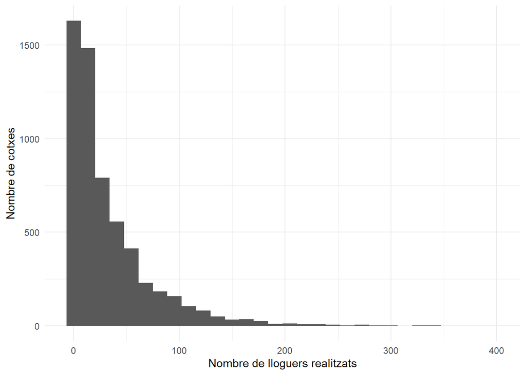

```r
lambda_optima <- BoxCoxLambda(ds$renterTripsTaken)
ds$renterTripsTaken_norm <- BoxCox(ds$renterTripsTaken, lambda = lambda_optima)

ggplot(ds, aes(x = renterTripsTaken)) + geom_histogram() + ylab("Nombre de cotxes") +
    xlab("Nombre de lloguers realitzats")
```

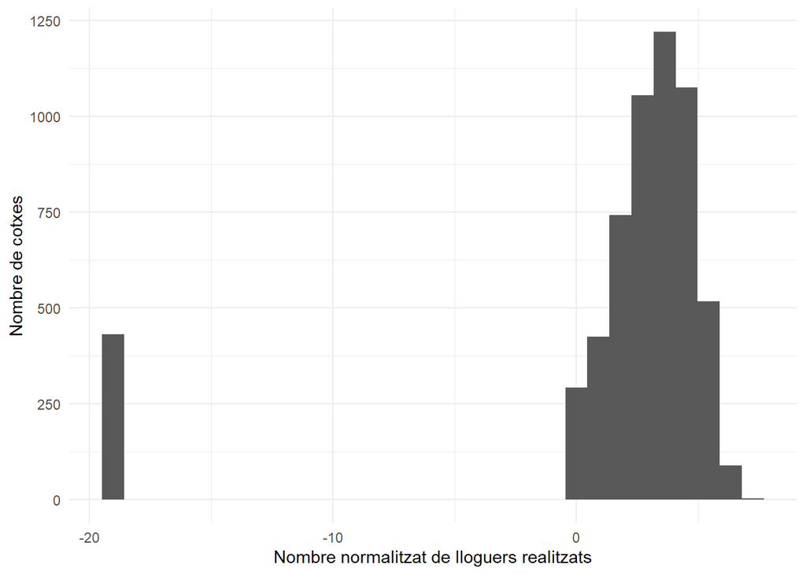

```r
ggplot(ds, aes(x = renterTripsTaken_norm)) + geom_histogram() +
    ylab("Nombre de cotxes") + xlab("Nombre normalitzat de lloguers realitzats")
```

Veiem que, tot i amb la conversió, no s’obté forma de distribució normal ja que queden un grup significatiu de valors aïllats.

**Normalització de reviewCount (Nombre de comentaris)**

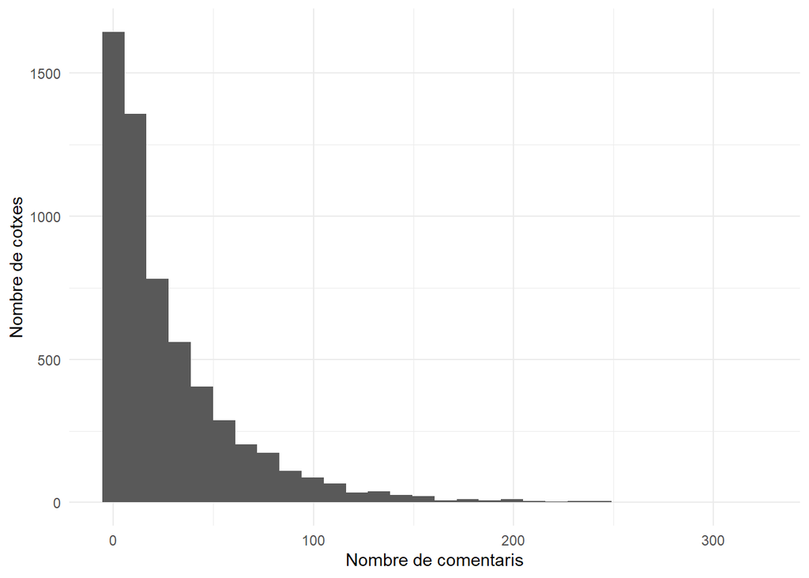

```r
lambda_optima <- BoxCoxLambda(ds$reviewCount)
ds$reviewCount_norm <- BoxCox(ds$reviewCount, lambda = lambda_optima)

ggplot(ds, aes(x = reviewCount)) + geom_histogram() + ylab("Nombre de cotxes") +
    xlab("Nombre de comentaris")
```

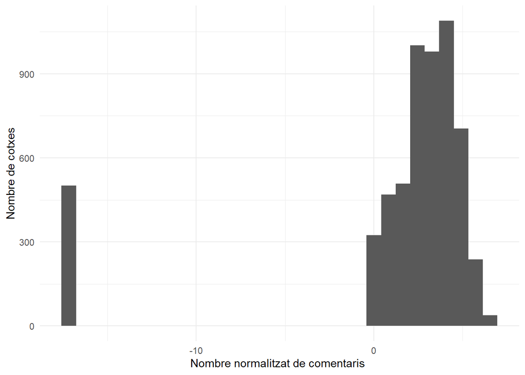

```r
ggplot(ds, aes(x = reviewCount_norm)) + geom_histogram() + ylab("Nombre de cotxes") +
    xlab("Nombre normalitzat de comentaris ")
```

Veiem que, tot i amb la conversió, no s’obté forma de distribució normal ja que queden un grup significatiu de valors aïllats.

**Normalització de vehicle.year (Any del cotxe)**

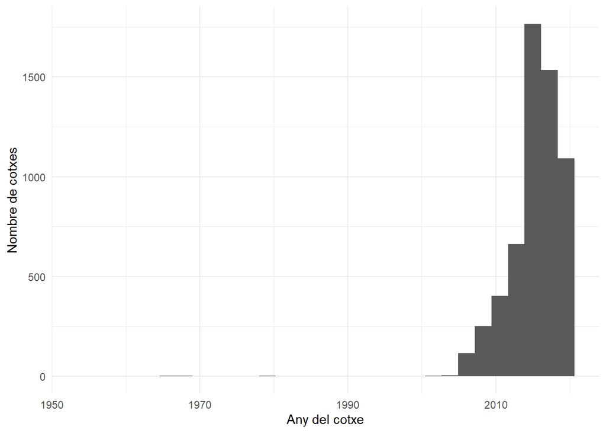

```r
lambda_optima <- BoxCoxLambda(ds$vehicle.year)
ds$vehicle.year_norm <- BoxCox(ds$vehicle.year, lambda = lambda_optima)

ggplot(ds, aes(x = vehicle.year)) + geom_histogram() + ylab("Nombre de cotxes") +
    xlab("Any del cotxe")
```

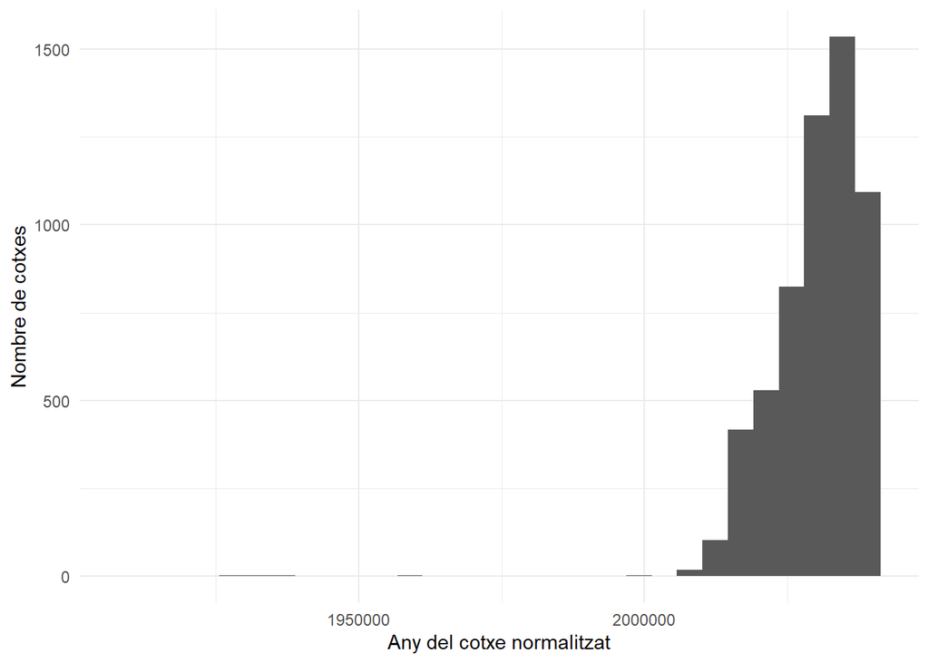

```r
ggplot(ds, aes(x = vehicle.year_norm)) + geom_histogram() + ylab("Nombre de cotxes") +
    xlab("Any del cotxe normalitzat")
```

Veiem que, tot i amb la conversió, no s’obté forma de distribució normal.

**Normalització de Income (Ingressos anuals del cotxe)**

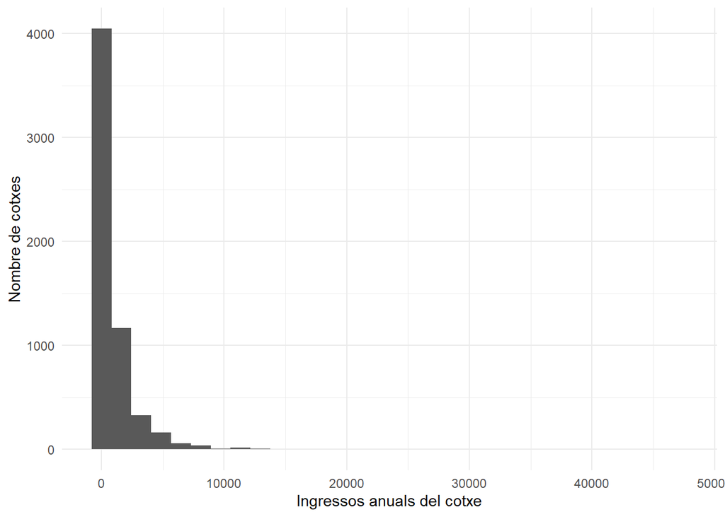

```r
lambda_optima <- BoxCoxLambda(ds$income)
ds$income_norm <- BoxCox(ds$income, lambda = lambda_optima)

ggplot(ds, aes(x = income)) + geom_histogram() + ylab("Nombre de cotxes") +
    xlab("Ingressos anuals del cotxe")
```

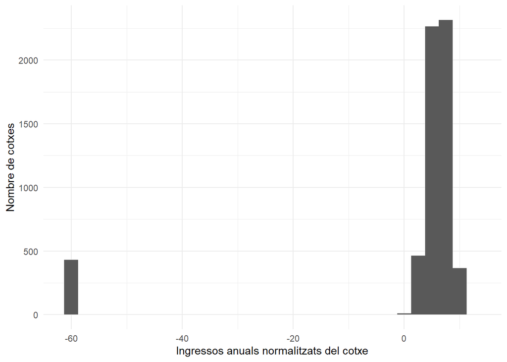

```r
ggplot(ds, aes(x = income_norm)) + geom_histogram() + ylab("Nombre de cotxes") +
    xlab("Ingressos anuals normalitzats del cotxe")
```

Veiem que, tot i amb la conversió, no s’obté forma de distribució normal ja que queden un grup significatiu de valors aïllats.

**Normalització de Frecuency (freqüència anual d’us del cotxe)**

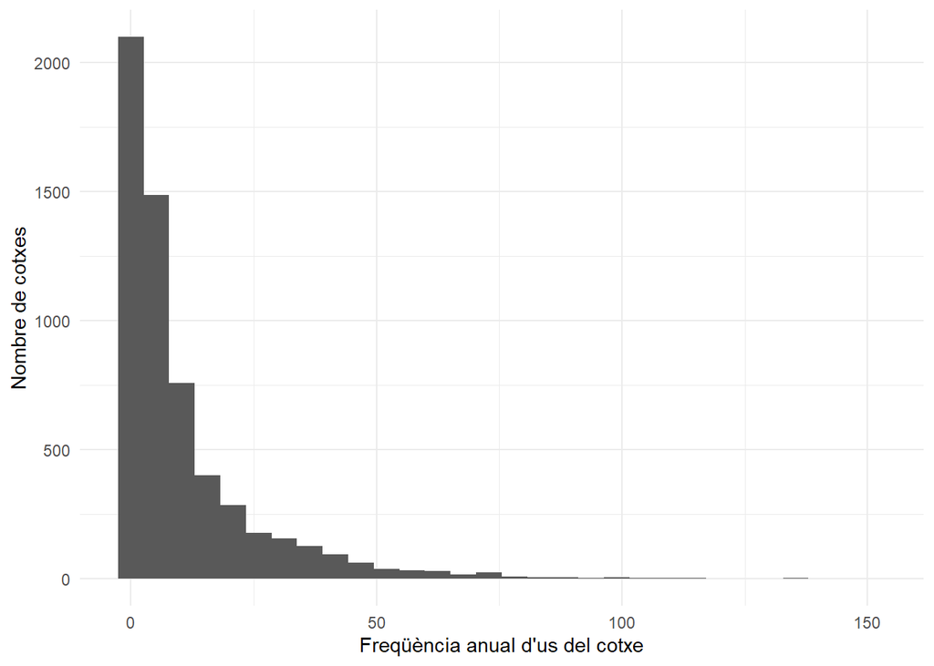

```r
lambda_optima <- BoxCoxLambda(ds$frequency)
ds$frequency_norm <- BoxCox(ds$frequency, lambda = lambda_optima)

ggplot(ds, aes(x = frequency)) + geom_histogram() + ylab("Nombre de cotxes") +
    xlab("Freqüència anual d'us del cotxe")
```

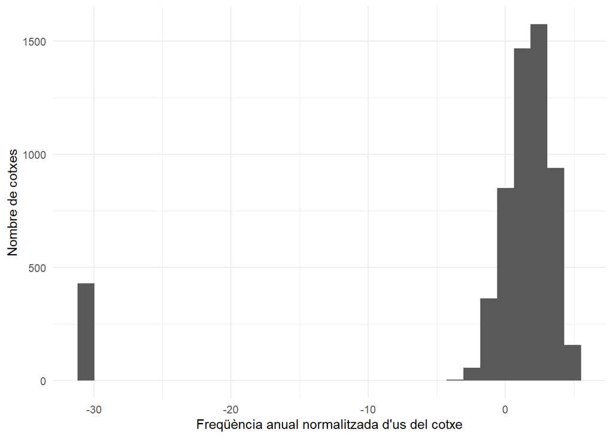

```r
ggplot(ds, aes(x = frequency_norm)) + geom_histogram() + ylab("Nombre de cotxes") +
    xlab("Freqüència anual normalitzada d'us del cotxe")
```

Veiem que, tot i amb la conversió, no s’obté forma de distribució normal ja que queden un grup significatiu de valors aïllats.

**Neteja de noves variables creades que no han tingut èxit en la normalització**

```r
# Eliminem location.country i les coordenades geogràfiques
ds <- subset(ds, select = -c(rating_norm, renterTripsTaken_norm,
    reviewCount_norm, vehicle.year_norm, income_norm, frequency_norm))

numeric_features_names = c("rating", "renterTripsTaken", "reviewCount",
    "rate.daily", "age", "income", "frequency")
```

**Anàlisi multivariant**

Per analitzar un conjunt de dades necessitem tenir en compte més d’una variable alhora. L’anàlisi bivariant permet identificar les relacions entre dues variables, i fins quina manera una pot predir l’altra.

En aquest cas podem veure quina és la relació entre el preu diari del lloguer i el nombre de vegades que s’ha llogat el vehicle amb un scatter plot o diagrama de punts.

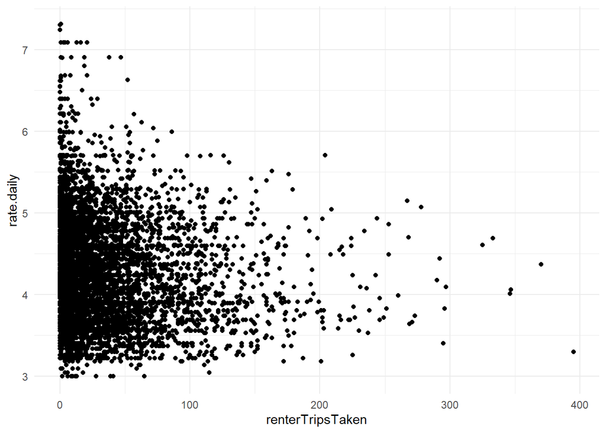

```r
# Relació entre el preu diari del lloguer i el nombre de
# vegades que s'ha llogat el vehicle
ggplot(ds, aes(x = renterTripsTaken, y = rate.daily)) + geom_point()
```

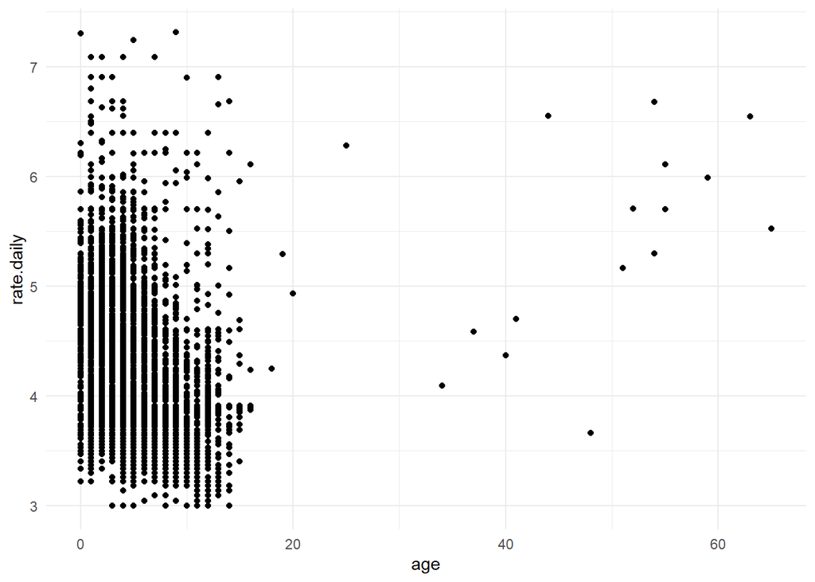

```r
# Relació entre el preu diari del lloguer i el nombre de
# vegades que s'ha llogat el vehicle
ggplot(ds, aes(x = age, y = rate.daily)) + geom_point()
```

En el cas d’una variable categòrica com el tipus de combustible o la marca del vehicle, podem visualitzar la relació amb un boxplot o diagrama de caixes.

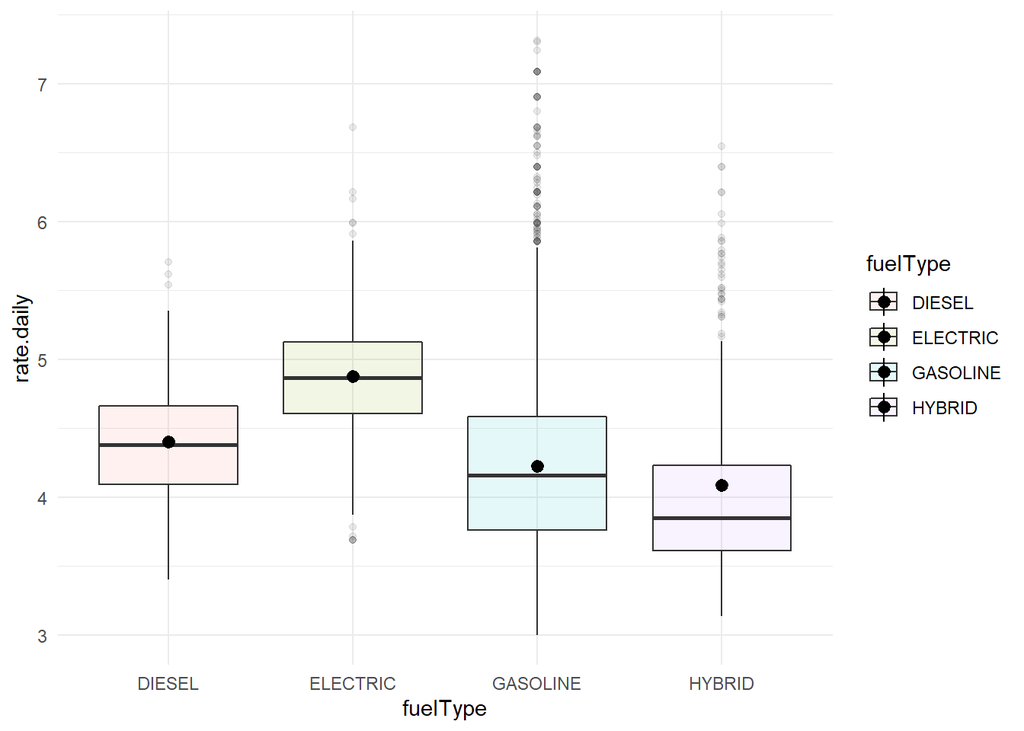

```r
# Relació entre el preu diari del lloguer i el tipus de
# combustible
ggplot(ds, aes(x = fuelType, y = rate.daily, fill = fuelType)) +
    geom_boxplot(alpha = 0.1) + stat_summary(fun.y = mean)
```

A partir del gràfic anterior podem observar com el tipus de combustible sembla que influeix al preu diari de lloguer. Essent el lloguer més car pels vehicles elèctrics i el més econòmic el dels vehicles híbrids. Mentre que el preu dels vehicles diesel i gasolina és similar.

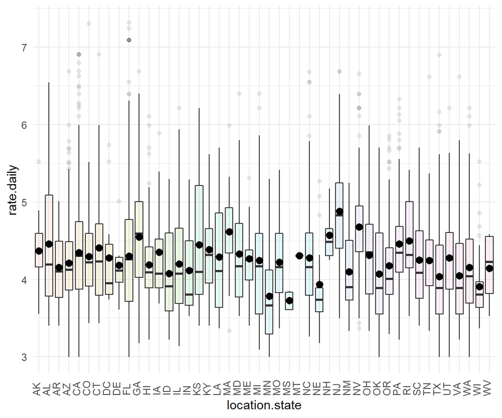

```r
# Relació entre el preu diari del lloguer i l'estat on es
# localitza el vehicle
ggplot(ds, aes(x = location.state, y = rate.daily, fill = location.state)) +
    geom_boxplot(alpha = 0.1) + stat_summary(fun.y = mean) +
    theme(axis.text.x = element_text(angle = 90, vjust = 0.1,
        hjust = 0.1)) + theme(legend.position = "none")
```

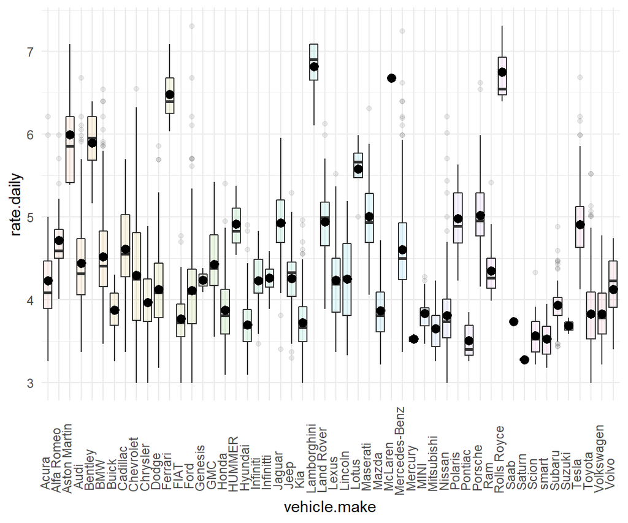

```r
# Relació entre el preu diari del lloguer i la marca del
# vehicle
ggplot(ds, aes(x = vehicle.make, y = rate.daily, fill = vehicle.make)) +
    geom_boxplot(alpha = 0.1) + stat_summary(fun.y = mean) +
    theme(axis.text.x = element_text(angle = 90, vjust = 0.1,
        hjust = 0.1)) + theme(legend.position = "none")
```

A partir del gràfic anterior podem observar com la marca del vehicle sembla que influeix al preu diari de lloguer. Essent el lloguer més car pels vehicles d’alta gama, com ja podiem intuir, on destaca *Rolls Royce, Lamborgini, Aston Martin i Ferrari*.

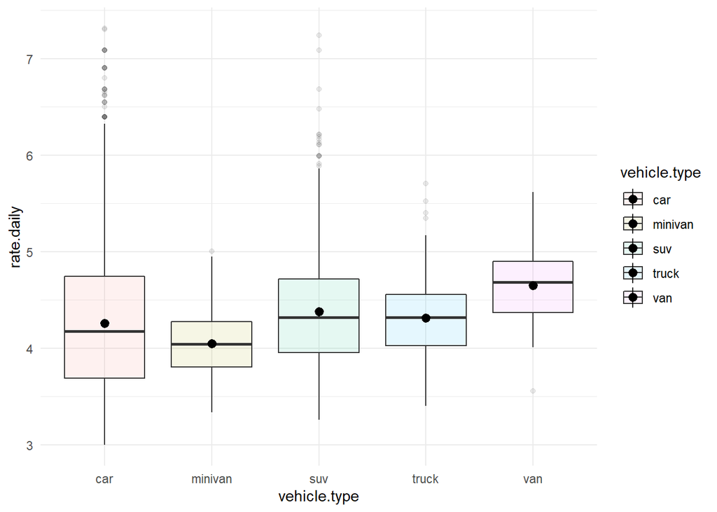

```r
# Relació entre el preu diari del lloguer i el tipus de
# vehicle
ggplot(ds, aes(x = vehicle.type, y = rate.daily, fill = vehicle.type)) +
    geom_boxplot(alpha = 0.1) + stat_summary(fun.y = mean)
```

A partir del gràfic anterior podem observar com el tipus del vehicle sembla que influeix al preu diari de lloguer. Essent el lloguer més car per les furgonetes (*van*), i el més econòmic per les mini furgonetes (*minivan*). Mentre que per la resta de tipus de vehicles *car, suv i truck* no s’observa una gran diferència en el preu.

Si volem visualitzar alhora les relacions creuades entre diverses variables, podem fer un pairplot.

Examinem els atributs numèrics envers si el vehicle va se llogat o no.

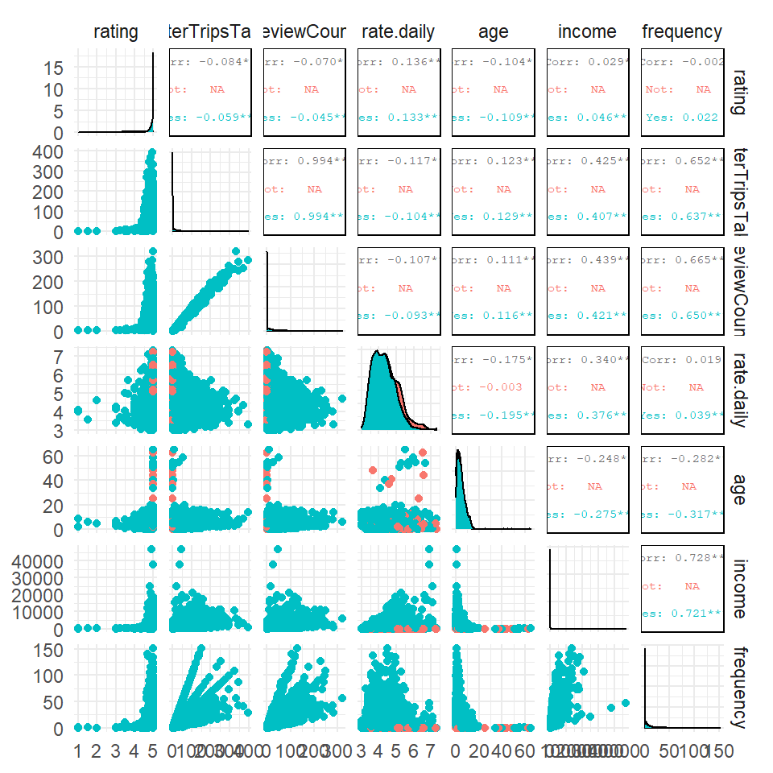

```r
ggpairs(ds, columns = numeric_features_names, mapping = aes(color = rent),
    upper = list(continuous = wrap("cor", size = 2)))
```

A partir del pairplot anterior veiem que hi ha un solapament entre totes les funcions de densitat, en funció de si va ser llogat o no el vehicle, amb la qual cosa podem determinar que no hi ha cap atribut numèric que ens permeti identificar si el vehicle va ser llogat o no directament. D’altre banda podem destacar la relació lineal que s’observa entre l’atribut *renderTripsTaken* i *reviewCount*, on tal i com podriem pensar quans més cops es lloga un vehicle més valoracions rep.

Examinem els atributs numèrics envers la qualificació que va obtenir el vehicle.

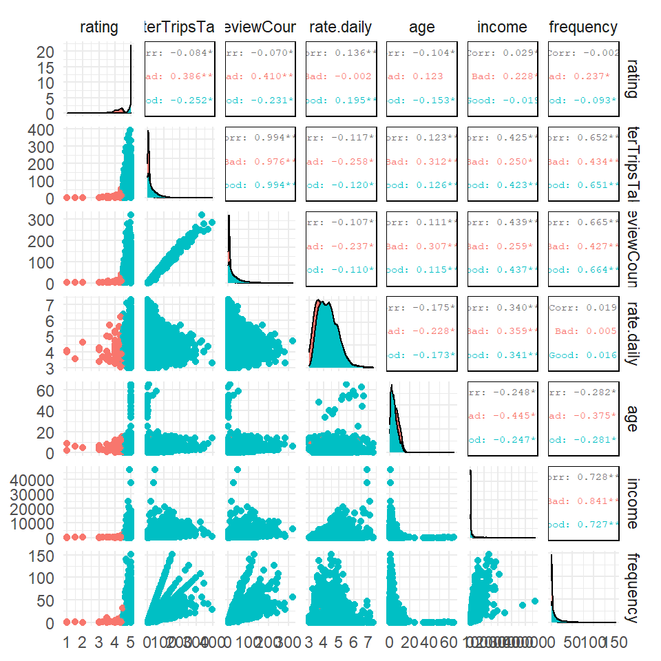

```r
ggpairs(ds, columns = numeric_features_names, mapping = aes(color = rating.discret),
    upper = list(continuous = wrap("cor", size = 2)))
```

A partir del pairplot anterior veiem que hi ha un solapament entre totes les funcions de densitat, en funció de la qualificació obtinguda pel vehicle de lloguer, amb la qual cosa podem determinar que no hi ha cap atribut numèric que ens permeti identificar la puntuació del vehicle directament. D’altre banda també s’observa la relació lineal que hi ha entre l’atribut *renderTripsTaken* i *reviewCount*, on tal i com podriem pensar quans més cops es lloga un vehicle més valoracions rep.

Finalment, ens interessarà veure quins conjunts de variables estan relacionats entre si. Per això, farem servir tècniques estadístiques d’anàlisi multivariant.

Una de les eines més útils és calcular la matriu de correlació entre les variables. Amb la funció qplot i la correlació de variables, calculada amb la funció cor, podem visualitzar de manera fàcil aquelles variables més correlacionades, que corresponen a una intensitat major de color.

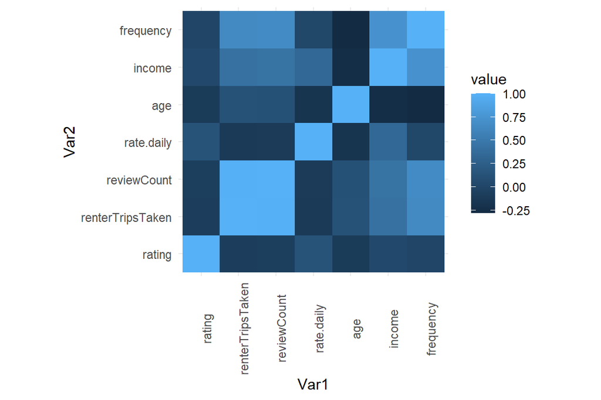

```r
heat <- ds[, numeric_features_names]
qplot(x = Var1, y = Var2, data = melt(cor(heat, use = "p")),
    fill = value, geom = "tile") + theme(axis.text.x = element_text(angle = 90)) +
    coord_fixed()
```

## 2.5 Test estadístics

En primer lloc, procedim a realitzar una anàlisi de correlació entre les diferents variables per determinar quines d’elles exerceixen una major influència sobre el preu diari del lloguer del vehicle. Per a això, s’utilitzarà el coeficient de correlació de Spearman, ja que hem vist que tenim dades que no segueixen una distribució normal.

```r
corr_matrix <- matrix(nc = 2, nr = 0)
colnames(corr_matrix) <- c("estimate", "p-value")

# Calcular el coeficiente de correlación para cada variable
# cuantitativa con respecto al campo 'precio'
for (i in 1:(ncol(ds) - 1)) {
    if (is.integer(ds[, i]) | is.numeric(ds[, i])) {
        spearman_test = cor.test(ds[, i], ds[, "rate.daily"],
            method = "spearman")
        corr_coef = spearman_test$estimate
        p_val = spearman_test$p.value

        # Add row to matrix
        pair = matrix(ncol = 2, nrow = 1)
        pair[1][1] = corr_coef
        pair[2][1] = p_val
        corr_matrix <- rbind(corr_matrix, pair)
        rownames(corr_matrix)[nrow(corr_matrix)] <- colnames(ds)[i]
    }
}

print(corr_matrix)
```

```
##                    estimate       p-value
## rating            0.2315008  4.931486e-72
## renterTripsTaken -0.1348053  3.905934e-25
## reviewCount      -0.1255619  5.388263e-22
## rate.daily        1.0000000  0.000000e+00
## vehicle.year      0.3014508 3.439955e-123
## age              -0.3014508 3.439955e-123
## income            0.3280650 7.504998e-147
```

Nota. Per a cada coeficient de correlació es mostra també el seu *p-valor* associat, ja que aquest pot donar informació sobre el pes estadístic de la correlació obtinguda.

### 2.5.2 ¿Els cotxes elèctric tenen un preu més elevat que els cotxes de benzina?

Per a avaluar si els cotxes elèctics tenen un preu de lloguer diari més elevat que els cotxes de benzina, podem aplicar un test d’hipòtesis de dues mostres. Tal i com veurem a continuació.

**Hipòtesi nul·la i alternativa**

Comencem amb la definició de la hipòtesi nul·la i de la hipòtesi alternativa.

- Hipòtesi nul·la:
  $$H_{0}: \mu_{1} = \mu_{2}$$
- Hipòtesi alternativa:
  $$H_{1}: \mu_{1} > \mu_{2}$$

A continuació revisem si es compleix l’assumpció de normalitat per a la variable ‘rate.daily’ i a partir d’això, podrem explicar quin test podem aplicar per al test d’hipòtesis de dues mostres.

**Test de normalitat**

En primer lloc avaluem l’assumpció de normalitat per a la variable ‘rate.daily’

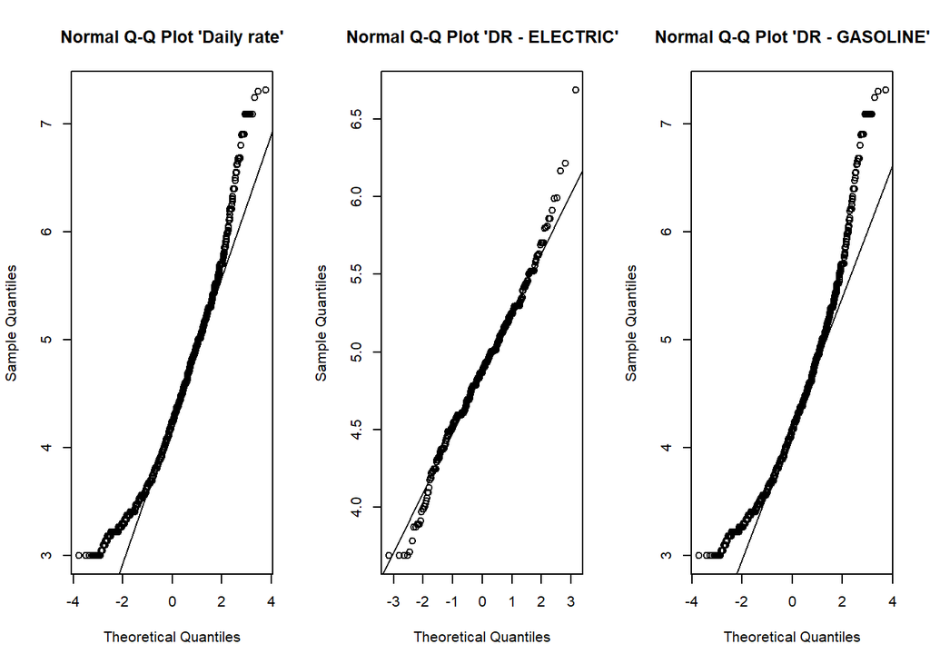

```r
par(mfrow = c(1, 3))
x <- ds$rate.daily
qq1 <- qqnorm(x, main = "Normal Q-Q Plot 'Daily rate'")
qqline(x)

x <- ds$rate.daily[ds$fuelType == "ELECTRIC"]
qq2 <- qqnorm(x, main = "Normal Q-Q Plot 'DR - ELECTRIC'")
qqline(x)

x <- ds$rate.daily[ds$fuelType == "GASOLINE"]
qq3 <- qqnorm(x, main = "Normal Q-Q Plot 'DR - GASOLINE'")
qqline(x)
```

**Test d’igualtat de variàncies**

Per a aplicar l’estadístic adequat, cal comprovar si les variàncies de les dues poblacions són iguals. Per això, apliquem primer el test d’igualtat de variàncies.

Per això podem realitzar un altre test, tal que:

- Hipòtesi nul·la:
  $$H_{0}: \sigma^{2}_{1} = \sigma^{2}_{2}$$
- Hipòtesi alternativa:
  $$H_{1}: \sigma^{2}_{1} \neq \sigma^{2}_{2}$$

```r
# Obtenim les dades
ELECTRIC <- ds$rate.daily[ds$fuelType == "ELECTRIC"]
GASOLINE <- ds$rate.daily[ds$fuelType == "GASOLINE"]

# Calculem el test d'igualtat de variàncies, amb la funció
# var.test d'R
var.test(ELECTRIC, GASOLINE)
```

```
##
##  F test to compare two variances
##
## data:  ELECTRIC and GASOLINE
## F = 0.39604, num df = 621, denom df = 4884, p-value < 2.2e-16
## alternative hypothesis: true ratio of variances is not equal to 1
## 95 percent confidence interval:
##  0.3528624 0.4469429
## sample estimates:
## ratio of variances
##            0.39604
```

Donat que el valor *p-value* obtingut és menor que el nivell de significació (0.05) podem rebutjar la hipòtesi nul·la i per tant podem dir que la variància de ambdues poblacions és diferent amb un nivell de confiança del 95%.

A partir dels resultats anteriors podem dir que el test a aplicar serà un test d’hipòtesis de dues mostres de poblacions independents amb distribucions normals i variàncies desconegudes i diferents.

**Test de la mitjana de dues mostres independents amb variància desconeguda i diferents**

Arribats aquest punt, amb la funció *t.test* d’R que ens permet realitzar el contrast d’hipòtesis directament, realitzem el test de mitjanes.

```r
# variàncies diferents
t.test(ds$rate.daily[ds$fuelType == "ELECTRIC"], ds$rate.daily[ds$fuelType ==
    "GASOLINE"], alternative = "greater", var.equal = FALSE)
```

```
##
##  Welch Two Sample t-test
##
## data:  ds$rate.daily[ds$fuelType == "ELECTRIC"] and ds$rate.daily[ds$fuelType == "GASOLINE"]
## t = 35.363, df = 1070.4, p-value < 2.2e-16
## alternative hypothesis: true difference in means is greater than 0
## 95 percent confidence interval:
##  0.6179538       Inf
## sample estimates:
## mean of x mean of y
##  4.874673  4.226547
```

El valor *p-value* obtingut és menor que el nivell de significació (0.05) i, per tant, podem rebutjar la hipòtesi nul·la d’igualtat de mitjanes de preu de lloguer diari entre els cotxes elèctris i els cotxes de benzina. Per tant podem dir que els cotxes électrics tenen un lloguer més elevat que els de benzina, amb un nivell de confiança del 95%.

### 2.5.3 ¿La proporció de furgonetes és més petit que la d’utilitaris?

Ara ens preguntem si la proporció de furgonetes de lloguer és més petit que la d’utilitaris o vehicles convencionals.

**Hipòtesi nul·la i alternativa**

Per tal de donar resposta a la pregunta formulada, comencem amb la definició de la hipòtesi nul·la i de la hipòtesi alternativa.

- Hipòtesi nul·la:
  $$H_{0}: p = 0.5$$
- Hipòtesi alternativa:
  $$H_{1}: p_{1} < 0.5$$

**Test unilateral d’una mostra sobre la proporció**

A continuació podem realitzar els càlculs pertinents que ens permetin decidir si podem rebutjar la hipòtest nul-la o no.

Podem fer servir, la funció prop.test pròpia d’R que ens permet realitzar directament contrastos d’hipòtesis sobre proporcions.

```r
n <- length(ds$vehicle.type)

prop.test(x = sum(ds$vehicle.type == "van" | ds$vehicle.type ==
    "minivan"), n = n, p = 0.5, alternative = "less", correct = FALSE)
```

```
##
##  1-sample proportions test without continuity correction
##
## data:  sum(ds$vehicle.type == "van" | ds$vehicle.type == "minivan") out of n, null probability 0.5
## X-squared = 4759.3, df = 1, p-value < 2.2e-16
## alternative hypothesis: true p is less than 0.5
## 95 percent confidence interval:
##  0.00000000 0.05390773
## sample estimates:
##          p
## 0.04905144
```

D’altra banda el *p-valor* és inferior al nivell de significació (*p-value < α*), per tant podem rebutjar la hipòtesi nul·la. Això ens permet dir que la proporció de furgonetes és més petita que la d’utilitàris, amb un nivell de confiança del 95%.

### 2.5.4 ¿El preu diari del lloguer del vehicle és diferent en funció del tipus de vehicle?

Per tal de donar resposta a aquesta pregunta, realitzarem un contrast de la igualtat de varianza mitjançant un test de *Bartlett* en dues o més poblacions sense la necessitat de que la mida dels grups que comparem sigui la mateixa.

```r
car <- ds[ds$vehicle.type == "car", "rate.daily"]
minivan <- ds[ds$vehicle.type == "minivan", "rate.daily"]
suv <- ds[ds$vehicle.type == "suv", "rate.daily"]
truck <- ds[ds$vehicle.type == "truck", "rate.daily"]
van <- ds[ds$vehicle.type == "van", "rate.daily"]

bartlett.test(list(car, minivan, suv, truck, van))
```

```
##
##  Bartlett test of homogeneity of variances
##
## data:  list(car, minivan, suv, truck, van)
## Bartlett's K-squared = 349.44, df = 4, p-value < 2.2e-16
```

Podem veure que tenim cinc grups diferents (5 categories de vehicles) que volem comparar. A partir del test realitzat hi ha evidències de que la varianza no és la mateixa en tots el grups. Fet que ja podiem intuir al diagrama de caixes o boxplot on mostravem l’atribut ‘rate.daily’ envers ‘vehicle.type.’

### 2.5.5 ¿El preu diari del lloguer del vehicle és diferent en funció del tipus de combustible?

Per tal de donar resposta a aquesta pregunta, realitzarem un contrast de la igualtat de varianza mitjançant un test de *Bartlett* en dues o més poblacions sense la necessitat de que la mida dels grups que comparem sigui la mateixa.

```r
diesel <- ds[ds$vehicle.type == "car", "rate.daily"]
electric <- ds[ds$vehicle.type == "minivan", "rate.daily"]
gasoline <- ds[ds$vehicle.type == "suv", "rate.daily"]
hybrid <- ds[ds$vehicle.type == "truck", "rate.daily"]

bartlett.test(list(diesel, electric, gasoline, hybrid))
```

```
##
##  Bartlett test of homogeneity of variances
##
## data:  list(diesel, electric, gasoline, hybrid)
## Bartlett's K-squared = 327.66, df = 3, p-value < 2.2e-16
```

## 2.6 Model de regressió lineal múltiple per preveure el preu diari d’un vehicle

A continuació ens proposem estimar per mínims quadrats ordinaris un model lineal que expliqui la variable *rate.daily* en funció de *age i renterTripsTaken*. En aquest cas farem servir només atributs numèrics.

**Model de regressió lineal múltiple 1 (Preu ~ age + renterTripsTaken)**

```r
model.lm1 <- lm(formula = rate.daily ~ age + renterTripsTaken,
    data = ds)

summary(model.lm1)
```

```
##
## Call:
## lm(formula = rate.daily ~ age + renterTripsTaken, data = ds)
##
## Residuals:
##     Min      1Q  Median      3Q     Max
## -1.3593 -0.4833 -0.0676  0.3867  3.7207
##
## Coefficients:
##                    Estimate Std. Error t value Pr(>|t|)
## (Intercept)       4.4620496  0.0137813 323.776  < 2e-16 ***
## age              -0.0260129  0.0020630 -12.609  < 2e-16 ***
## renterTripsTaken -0.0014895  0.0001995  -7.468 9.34e-14 ***
## ---
## Signif. codes:  0 '***' 0.001 '**' 0.01 '*' 0.05 '.' 0.1 ' ' 1
##
## Residual standard error: 0.6343 on 5848 degrees of freedom
## Multiple R-squared:  0.03969,    Adjusted R-squared:  0.03936
## F-statistic: 120.8 on 2 and 5848 DF,  p-value: < 2.2e-16
```

Així doncs l’equació de regressió és:

$$\hat{y} = -0.0260*age - 0.0014 * renterTripsTaken + 4.46$$

Es pot observar que tant la variable *age i renterTripsTaken* són significatives perquè Pr(>|t|)< 0,05.

Finalment el coeficient de determinació ajustat per aquest model és: R<sup>2</sup> = 0.03936. Això ens diu que el model de regressió múltiple obtingut explica el 3.936% de la variabilitat del preu del lloguer diari de vehicles. Com que és molt proper al 0%, en principi és un model bastant dolent, i per tant tindrà poc poder predictiu, gairebè nul.

Anem a veure ara si amb la introducció de noves variables al model, aconseguim un altre model que presenti una millor capacitat predictora. En aquest cas utilitzarem només atributs categòrics.

```r
model.lm2 <- lm(formula = rate.daily ~ fuelType + vehicle.make +
    vehicle.type, data = ds)

summary(model.lm2)
```

```
##
## Call:
## lm(formula = rate.daily ~ fuelType + vehicle.make + vehicle.type,
##     data = ds)
##
## Residuals:
##     Min      1Q  Median      3Q     Max
## -1.5042 -0.2904 -0.0467  0.2319  3.2925
##
## Coefficients:
##                           Estimate Std. Error t value Pr(>|t|)
## (Intercept)                4.07857    0.08558  47.660  < 2e-16 ***
## fuelTypeELECTRIC           0.12842    0.08956   1.434 0.151657
## fuelTypeGASOLINE           0.06059    0.05655   1.071 0.284061
## fuelTypeHYBRID             0.14366    0.06377   2.253 0.024314 *
## vehicle.makeAlfa Romeo     0.51483    0.10341   4.978 6.59e-07 ***
## vehicle.makeAston Martin   1.85343    0.21013   8.820  < 2e-16 ***
## vehicle.makeAudi           0.24866    0.07218   3.445 0.000575 ***
## vehicle.makeBentley        1.75575    0.16230  10.818  < 2e-16 ***
## vehicle.makeBMW            0.33877    0.06691   5.063 4.25e-07 ***
## vehicle.makeBuick         -0.35930    0.12065  -2.978 0.002913 **
## vehicle.makeCadillac       0.37954    0.09254   4.101 4.16e-05 ***
## vehicle.makeChevrolet      0.07429    0.06714   1.106 0.268563
## vehicle.makeChrysler      -0.26103    0.08852  -2.949 0.003201 **
## vehicle.makeDodge         -0.11999    0.07263  -1.652 0.098600 .
## vehicle.makeFerrari        2.34670    0.13961  16.809  < 2e-16 ***
## vehicle.makeFIAT          -0.37648    0.09404  -4.003 6.33e-05 ***
## vehicle.makeFord          -0.12850    0.06722  -1.912 0.055954 .
## vehicle.makeGenesis        0.09903    0.32291   0.307 0.759093
## vehicle.makeGMC            0.07140    0.08444   0.846 0.397822
## vehicle.makeHonda         -0.34821    0.06964  -5.000 5.90e-07 ***
## vehicle.makeHUMMER         0.61240    0.26618   2.301 0.021443 *
## vehicle.makeHyundai       -0.47097    0.07164  -6.574 5.33e-11 ***
## vehicle.makeInfiniti      -0.01211    0.09634  -0.126 0.899951
## vehicle.makeInfinitti      0.06546    0.17048   0.384 0.701011
## vehicle.makeJaguar         0.76627    0.08662   8.846  < 2e-16 ***
## vehicle.makeJeep          -0.05534    0.06906  -0.801 0.422959
## vehicle.makeKia           -0.47577    0.07318  -6.501 8.64e-11 ***
## vehicle.makeLamborghini    2.65612    0.13194  20.132  < 2e-16 ***
## vehicle.makeLand Rover     0.64085    0.07884   8.128 5.28e-16 ***
```

[output cut: 21 more lines]

```
## vehicle.makeSuzuki        -0.53811    0.32280  -1.667 0.095571 .
## vehicle.makeTesla          0.66804    0.09531   7.009 2.67e-12 ***
## vehicle.makeToyota        -0.40604    0.06633  -6.122 9.85e-10 ***
## vehicle.makeVolkswagen    -0.33633    0.07460  -4.508 6.66e-06 ***
## vehicle.makeVolvo         -0.11214    0.11453  -0.979 0.327547
## vehicle.typeminivan        0.18399    0.03392   5.425 6.03e-08 ***
## vehicle.typesuv            0.16562    0.01498  11.056  < 2e-16 ***
## vehicle.typetruck          0.34791    0.03631   9.581  < 2e-16 ***
## vehicle.typevan            0.46727    0.06255   7.470 9.19e-14 ***
## ---
## Signif. codes:  0 '***' 0.001 '**' 0.01 '*' 0.05 '.' 0.1 ' ' 1
##
## Residual standard error: 0.4476 on 5792 degrees of freedom
## Multiple R-squared:  0.5263, Adjusted R-squared:  0.5215
## F-statistic: 110.9 on 58 and 5792 DF,  p-value: < 2.2e-16
```

**Model de regressió lineal mùltiple 3 (Preu ~ age + renterTripsTaken + fuelType + vehicle.make + vehicle.type)**

Ara probarem a generar un nou model, però aquest cop combinarem atributs categòrics i atributs numèrics com a variables predictores.

```r
model.lm3 <- lm(formula = rate.daily ~ age + renterTripsTaken +
    fuelType + vehicle.make + vehicle.type, data = ds)

summary(model.lm3)
```

```
##
## Call:
## lm(formula = rate.daily ~ age + renterTripsTaken + fuelType +
##     vehicle.make + vehicle.type, data = ds)
##
## Residuals:
##     Min      1Q  Median      3Q     Max
## -1.4679 -0.2848 -0.0452  0.2218  3.5250
##
## Coefficients:
##                             Estimate Std. Error t value Pr(>|t|)
## (Intercept)                4.2130533  0.0850090  49.560  < 2e-16 ***
## age                       -0.0180556  0.0015212 -11.869  < 2e-16 ***
## renterTripsTaken          -0.0005816  0.0001420  -4.096 4.26e-05 ***
## fuelTypeELECTRIC           0.0669143  0.0884178   0.757 0.449202
## fuelTypeGASOLINE           0.0365918  0.0558051   0.656 0.512039
## fuelTypeHYBRID             0.1166809  0.0629126   1.855 0.063697 .
## vehicle.makeAlfa Romeo     0.4754037  0.1020847   4.657 3.28e-06 ***
## vehicle.makeAston Martin   1.9065986  0.2072394   9.200  < 2e-16 ***
## vehicle.makeAudi           0.2444201  0.0711658   3.435 0.000598 ***
## vehicle.makeBentley        1.8216577  0.1601342  11.376  < 2e-16 ***
## vehicle.makeBMW            0.3425849  0.0659879   5.192 2.16e-07 ***
## vehicle.makeBuick         -0.3516728  0.1189432  -2.957 0.003123 **
## vehicle.makeCadillac       0.3618130  0.0912419   3.965 7.41e-05 ***
## vehicle.makeChevrolet      0.0760419  0.0662462   1.148 0.251070
## vehicle.makeChrysler      -0.2577408  0.0872665  -2.953 0.003155 **
## vehicle.makeDodge         -0.1381877  0.0716509  -1.929 0.053826 .
## vehicle.makeFerrari        2.3948421  0.1377051  17.391  < 2e-16 ***
## vehicle.makeFIAT          -0.3427483  0.0927643  -3.695 0.000222 ***
## vehicle.makeFord          -0.1207580  0.0662857  -1.822 0.068540 .
## vehicle.makeGenesis        0.0496733  0.3183620   0.156 0.876017
## vehicle.makeGMC            0.0801600  0.0832524   0.963 0.335660
## vehicle.makeHonda         -0.3292030  0.0687134  -4.791 1.70e-06 ***
## vehicle.makeHUMMER         0.7485767  0.2626601   2.850 0.004388 **
## vehicle.makeHyundai       -0.4940905  0.0706814  -6.990 3.05e-12 ***
## vehicle.makeInfiniti      -0.0081172  0.0949801  -0.085 0.931897
## vehicle.makeInfinitti      0.0131642  0.1681283   0.078 0.937593
## vehicle.makeJaguar         0.7528006  0.0854220   8.813  < 2e-16 ***
## vehicle.makeJeep          -0.0630679  0.0681555  -0.925 0.354821
## vehicle.makeKia           -0.4911928  0.0721796  -6.805 1.11e-11 ***
```

[output cut: 23 more lines]

```
## vehicle.makeSuzuki        -0.4024606  0.3185544  -1.263 0.206497
## vehicle.makeTesla          0.6538991  0.0940838   6.950 4.05e-12 ***
## vehicle.makeToyota        -0.3732868  0.0654905  -5.700 1.26e-08 ***
## vehicle.makeVolkswagen    -0.3320440  0.0735458  -4.515 6.46e-06 ***
## vehicle.makeVolvo         -0.1356988  0.1129203  -1.202 0.229520
## vehicle.typeminivan        0.1908107  0.0334808   5.699 1.26e-08 ***
## vehicle.typesuv            0.1507442  0.0148286  10.166  < 2e-16 ***
## vehicle.typetruck          0.3159982  0.0359165   8.798  < 2e-16 ***
## vehicle.typevan            0.4352772  0.0618190   7.041 2.13e-12 ***
## ---
## Signif. codes:  0 '***' 0.001 '**' 0.01 '*' 0.05 '.' 0.1 ' ' 1
##
## Residual standard error: 0.4413 on 5790 degrees of freedom
## Multiple R-squared:  0.5398, Adjusted R-squared:  0.535
## F-statistic: 113.2 on 60 and 5790 DF,  p-value: < 2.2e-16
```

## 2.7 Model d’arbre de regressió per preveure el preu diari d’un vehicle

Comencem triant el subconjunt d’entrenament i el de prova. Nosaltres crearem dos conjunts de dades directament amb un rang.

```r
# Creem el conjunt d'entrenament i el de prova
set.seed(555)
indexes = sample(1:nrow(ds), size = floor((2/3) * nrow(ds)))
train <- ds[indexes, ]
test <- ds[-indexes, ]
```

Després d’una extracció aleatòria de casos cal realitzar una anàlisi de dades mínim per assegurar-nos de no obtenir valors esbiaixats pels valors que conté cada mostra.

```r
# Verifiquem les dimensions del conjunt d'entrenament
dim(train)
```

```
## [1] 3900   18
```

```r
# Verifiquem les dimensions del conjunt de prova
dim(test)
```

```
## [1] 1951   18
```

```r
# Obtenim l'atribut de classe de la resta
trainY <- train[, c("rate.daily")]
testY <- test[, c("rate.daily")]
```

**Model d’Arbre de regressió**

A continuació ens proposem generar un model d’arbre de regressió que expliqui la variable *rate.daily* en funció de les característiques del vehicle.

[figure not shown]

```r
# Generem el model d'arbre
model_cart_rate <- rpart(rate.daily ~ fuelType + location.city +
    location.state + vehicle.make + vehicle.model + vehicle.type,
    method = "anova", data = train)

# Mostrem un resum de la generació de l'arbre
# summary(model_cart)

# printcp(model_cart_rate)

# Mostrem en un gràfic l'arbre obtingut
rpart.plot(model_cart_rate)
```

Un cop generat el model, podem comprovar la seva qualitat predint la classe per a les dades de prova que hem reservat al principi.

```r
predicted_model_cart_rate <- predict(model_cart_rate, test, type = "vector")

# test RMSE
rmse_cart_rate <- rmse(predicted_model_cart_rate, testY)

# test MAE
mae_cart_rate <- mae(predicted_model_cart_rate, testY)

print(sprintf("RMSE: %.4f", rmse_cart_rate))
```

```
## [1] "RMSE: 0.3826"
```

```r
print(sprintf("MAE: %.4f", rmse_cart_rate))
```

[output not shown]

Examinem els valors predits envers els valors reals.

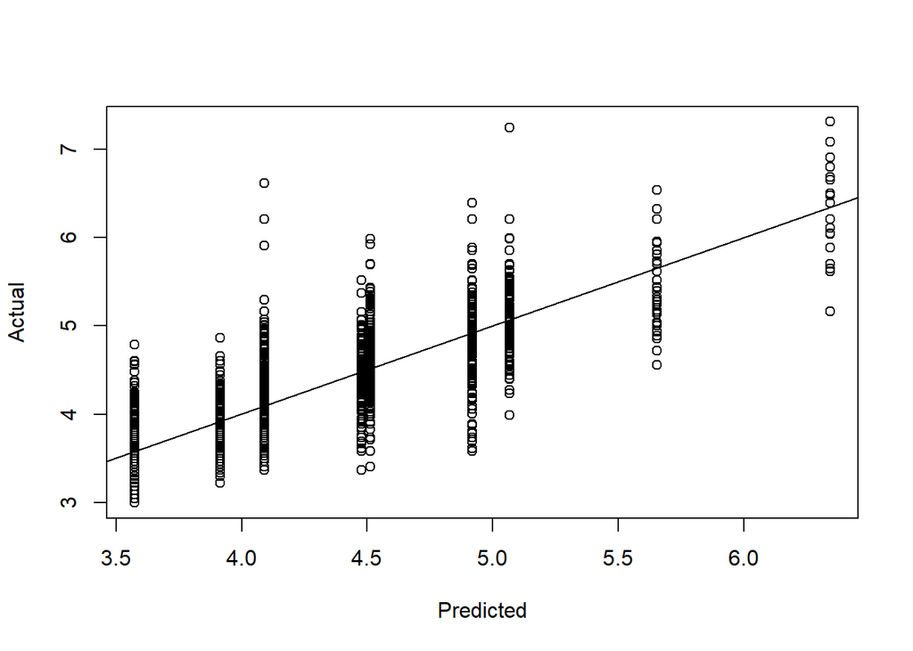

```r
plot(predicted_model_cart_rate, testY, xlab = "Predicted", ylab = "Actual")
abline(0, 1)
```

Examinem la importància de cada una dels atributs predictors en el model.

```r
model_cart_rate$variable.importance
```

```
##  vehicle.model   vehicle.make  location.city       fuelType location.state
##     1211.96274      636.94762      545.53745      239.29902      127.07061
##   vehicle.type
##       49.25973
```

A partir del resultat obtingut podem veure que l’atribut que més influeix en el preu del lloguer dels vehicles és el model de cotxe.

## 2.8 Model d’arbre de classificació per preveure si un vehicle serà llogat

A continuació ens proposem generar un model d’arbre de classificació que expliqui la variable *rent* en funció de les característiques del vehicle. És a dir que ens permeti donades les característiques d’un vehicle predir si aquest serà llogat o no.

**Model d’Arbre de classificació**

Obtenim la classe objectiu

```r
# Obtenim l'atribut de classe de la resta
trainY <- train[, c("rent")]
testY <- test[, c("rent")]
```

[figure not shown]

```r
# Generem el model d'arbre
model_cart_rent <- rpart(rent ~ fuelType + location.city + location.state +
    vehicle.make + vehicle.model + vehicle.type, method = "class",
    data = train)

# Mostrem un resum de la generació de l'arbre
# summary(model_cart)

# printcp(model_cart_rent)

# Mostrem en un gràfic l'arbre obtingut
rpart.plot(model_cart_rent)
```

Un cop generat el model, podem comprovar la seva qualitat predint la classe per a les dades de prova que hem reservat al principi.

```r
predicted_model_cart_rent <- predict(model_cart_rent, test, type = "class")

print(sprintf("La precisió de l'arbre és: %.4f %%", 100 * sum(predicted_model_cart_rent ==
    testY)/length(predicted_model_cart_rent)))
```

```
## [1] "La precisió de l'arbre és: 89.9539 %"
```

Quan hi ha poques classes, la qualitat de la predicció també es pot analitzar mitjançant una matriu de confusió que identifica els tipus d’errors comesos.

```r
mat_conf_cart_rent <- table(testY, Predicted = predicted_model_cart_rent)

mat_conf_cart_rent
```

```
##      Predicted
## testY  Not  Yes
##   Not    6  134
##   Yes   62 1749
```

Una altra manera de calcular el percentatge de registres correctament classificats és utilitzant la matriu de confusió:

```r
porcentaje_correct <- 100 * sum(diag(mat_conf_cart_rent))/sum(mat_conf_cart_rent)
print(sprintf("El %% de registres correctament classificats és: %.4f %%",
    porcentaje_correct))
```

```
## [1] "El % de registres correctament classificats és: 89.9539 %"
```

A més, tenim a la nostra disposició el paquet gmodels per a obtenir informació més completa

```r
CrossTable(testY, predicted_model_cart_rent, prop.chisq = FALSE,
    prop.c = FALSE, prop.r = FALSE, dnn = c("Reality", "Prediction"))
```

```
##
##
##    Cell Contents
## |-------------------------|
## |                       N |
## |         N / Table Total |
## |-------------------------|
##
##
## Total Observations in Table:  1951
##
##
##              | Prediction
##      Reality |       Not |       Yes | Row Total |
## -------------|-----------|-----------|-----------|
##          Not |         6 |       134 |       140 |
##              |     0.003 |     0.069 |           |
## -------------|-----------|-----------|-----------|
##          Yes |        62 |      1749 |      1811 |
##              |     0.032 |     0.896 |           |
## -------------|-----------|-----------|-----------|
## Column Total |        68 |      1883 |      1951 |
## -------------|-----------|-----------|-----------|
##
##
```

Durant tot l’estudi previ em deixat de banda un fet important que es va veure durant la fase d’anàlisis del joc de dades. Si recordem el nombre d’observacions pertanyents a una classe respecte a l’altre és força diferent per a l’atribut objectiu ‘rent.’

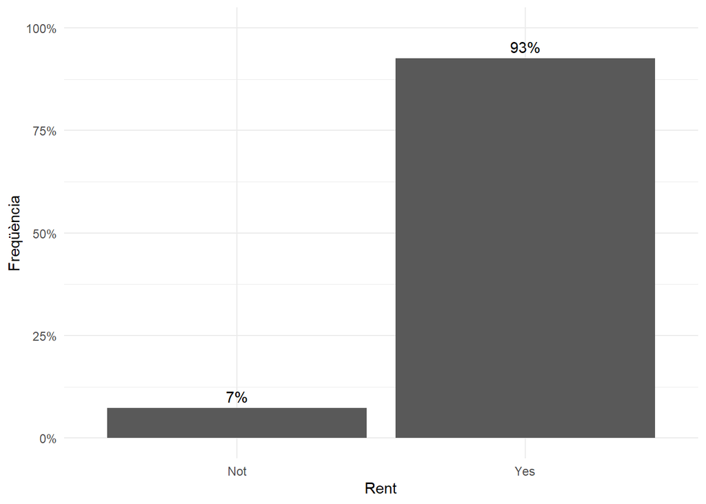

```r
# Calculem histogrames de les variables de classe
ggplot(data = ds, aes(x = rent)) + geom_bar(aes(y = (..count..)/sum(..count..))) +
    geom_text(aes(y = ((..count..)/sum(..count..)), label = scales::percent((..count..)/sum(..count..))),
        stat = "count", vjust = -0.5) + scale_y_continuous(labels = scales::percent,
    limits = c(0, 1)) + xlab("Rent") + ylab("Freqüència")
```

Les classificacions desequilibrades suposen un desafiament per a la generació de models de predicció, ja que la majoria dels algorismes utilitzats per a la classificació van ser dissenyats entorn l’assumpció d’un nombre igual d’observacions per a cada classe. Aixó produeix que els models obtinguts presentin un rendiment predictiu deficient, en concret per a la classe minoritària. A més aixó sol ser un problema perqué normalment, la classe minoritària és la més important i per tant el model és més sensible als errors de classificació de la classe minoritària que la classe majoritària.

Per tal de reduir els efectes causats per aquest fet proposem aplicar diferents mètodes de submostreig abans de generar els models.

```r
set.seed(2)

# Escollim els atributs sobre els quals treballarem
train.data <- train

train.data[, "Class"] <- train["rent"]

test.data <- test

test.data[, "Class"] <- test["rent"]

# Construïm diferents mostres a partir del conjunt de dades
# original

# Down sampling
down_train <- downSample(x = train.data[, -ncol(train.data)],
    y = train.data$Class)

# Up Sampling
up_train <- upSample(x = train.data[, -ncol(train.data)], y = train.data$Class)

# Mix up/down sampling SMOTE
smote_train <- SMOTE(Class ~ ., data = train.data)

# Mostrem el nombre d'observacions pertanyents a cada una de
# les clases després de la generació de mostres Conjunt
# original
table(train.data$Class)
```

```
##
##  Not  Yes
##  291 3609
```

```r
# Down sampling
table(down_train$Class)
```

```
##
## Not Yes
## 291 291
```

```r
# Up sampling
table(up_train$Class)
```

```
##
##  Not  Yes
## 3609 3609
```

```r
# Smote sampling
table(smote_train$Class)
```

```
##
##  Not  Yes
##  873 1164
```

Un cop obtingudes diferents mostres del conjunt de dades originals amb submostreig anem a realitzar l’entrenament d’un model d’arbre de decisió (CART) per cada un dels subconjunts.

```r
# Model training - CART
set.seed(4)
down_outside <- rpart(rent ~ fuelType + location.city + location.state +
    vehicle.make + vehicle.model + vehicle.type, method = "class",
    data = down_train)

set.seed(5)
up_outside <- rpart(rent ~ fuelType + location.city + location.state +
    vehicle.make + vehicle.model + vehicle.type, method = "class",
    data = up_train)

set.seed(6)
smote_outside <- rpart(rent ~ fuelType + location.city + location.state +
    vehicle.make + vehicle.model + vehicle.type, method = "class",
    data = smote_train)
```

I per acabar realitzem les corresponents predicions en el conjunt de test

```r
predicted_model_cart_rent <- predict(down_outside, test.data,
    type = "class")

print(sprintf("La precisió de l'arbre amb downsampling és: %.4f %%",
    100 * sum(predicted_model_cart_rent == test.data[, "Class"])/length(predicted_model_cart_rent)))
```

```
## [1] "La precisió de l'arbre amb downsampling és: 60.4305 %"
```

```r
predicted_model_cart_rent <- predict(up_outside, test.data, type = "class")

print(sprintf("La precisió de l'arbre amb upsampling és: %.4f %%",
    100 * sum(predicted_model_cart_rent == test.data[, "Class"])/length(predicted_model_cart_rent)))
```

```
## [1] "La precisió de l'arbre amb upsampling és: 73.4495 %"
```

```r
predicted_model_cart_rent <- predict(smote_outside, test.data,
    type = "class")

print(sprintf("La precisió de l'arbre amb smote sampling és: %.4f %%",
    100 * sum(predicted_model_cart_rent == test.data[, "Class"])/length(predicted_model_cart_rent)))
```

```
## [1] "La precisió de l'arbre amb smote sampling és: 78.9339 %"
```

## 2.9 Conclusions

A l’inici d’aquest estudi ens proposavem realitzar una anàlisi detallada dels atributs propis del sector del lloguer de vehicles per tal d’extreuren nou coneixement i que aquest pugui aportar valor.

Per això hem començat el nostre estudi amb les tasques típiques d’un procés de mineria o anàlica de dades, incloent la neteja de dades, la imputació de valors nuls, el tractament de valors extrems, la transformació d’alguns atributs i la creació d’atributs nous. També hem realitzat una primera inspecció visual de les dades on ja s’han pogut determinar certes relacions entre variables. Com per exemple que el preu diari de lloguer depén de la marca i el tipus de vehicle, el combustible que utilitza o la seva ubicació.

A continuació hem generat un model que permet preveure el preu per dia d’un automòbil de lloguer, a partir de les seves característiques. Tant mitjançant un model basat en regressió lineal múltiple com amb un arbre de regressió. Tot i que la capacitat predictiva obinguda per aquest dos models no ha sigut gaire bona, ens ha permés determinar que els atributs més influents en el preu diari de vehicles són el model i la marca del vehicle i la seva localització.

Finalment hem generat també un model que permet preveure, donades les característiques d’un vehicle de lloguer, si aquest serà llogat o no mitjançant un arbre de decisió per a classificació.

# 3 Bibliografia